# Red Wine Analysis by Manish Kumar

First of all let’s see the structure of the data

```
## 'data.frame':    1599 obs. of  13 variables:
##  $ X                   : int  1 2 3 4 5 6 7 8 9 10 ...
##  $ fixed.acidity       : num  7.4 7.8 7.8 11.2 7.4 7.4 7.9 7.3 7.8 7.5 ...
##  $ volatile.acidity    : num  0.7 0.88 0.76 0.28 0.7 0.66 0.6 0.65 0.58 0.5 ...
##  $ citric.acid         : num  0 0 0.04 0.56 0 0 0.06 0 0.02 0.36 ...
##  $ residual.sugar      : num  1.9 2.6 2.3 1.9 1.9 1.8 1.6 1.2 2 6.1 ...
##  $ chlorides           : num  0.076 0.098 0.092 0.075 0.076 0.075 0.069 0.065 0.073 0.071 ...
##  $ free.sulfur.dioxide : num  11 25 15 17 11 13 15 15 9 17 ...
##  $ total.sulfur.dioxide: num  34 67 54 60 34 40 59 21 18 102 ...
##  $ density             : num  0.998 0.997 0.997 0.998 0.998 ...
##  $ pH                  : num  3.51 3.2 3.26 3.16 3.51 3.51 3.3 3.39 3.36 3.35 ...
##  $ sulphates           : num  0.56 0.68 0.65 0.58 0.56 0.56 0.46 0.47 0.57 0.8 ...
##  $ alcohol             : num  9.4 9.8 9.8 9.8 9.4 9.4 9.4 10 9.5 10.5 ...
##  $ quality             : int  5 5 5 6 5 5 5 7 7 5 ...
```

There is a variable x which is as an index for the rows but we don’t need that so let’s remove this column

Now summaries every variable

```
##  fixed.acidity   volatile.acidity  citric.acid    residual.sugar
##  Min.   : 4.60   Min.   :0.1200   Min.   :0.000   Min.   : 0.900
##  1st Qu.: 7.10   1st Qu.:0.3900   1st Qu.:0.090   1st Qu.: 1.900
##  Median : 7.90   Median :0.5200   Median :0.260   Median : 2.200
##  Mean   : 8.32   Mean   :0.5278   Mean   :0.271   Mean   : 2.539
##  3rd Qu.: 9.20   3rd Qu.:0.6400   3rd Qu.:0.420   3rd Qu.: 2.600
##  Max.   :15.90   Max.   :1.5800   Max.   :1.000   Max.   :15.500
##    chlorides       free.sulfur.dioxide total.sulfur.dioxide
##  Min.   :0.01200   Min.   : 1.00       Min.   :  6.00
##  1st Qu.:0.07000   1st Qu.: 7.00       1st Qu.: 22.00
##  Median :0.07900   Median :14.00       Median : 38.00
##  Mean   :0.08747   Mean   :15.87       Mean   : 46.47
##  3rd Qu.:0.09000   3rd Qu.:21.00       3rd Qu.: 62.00
##  Max.   :0.61100   Max.   :72.00       Max.   :289.00
##     density             pH          sulphates         alcohol
##  Min.   :0.9901   Min.   :2.740   Min.   :0.3300   Min.   : 8.40
##  1st Qu.:0.9956   1st Qu.:3.210   1st Qu.:0.5500   1st Qu.: 9.50
##  Median :0.9968   Median :3.310   Median :0.6200   Median :10.20
##  Mean   :0.9967   Mean   :3.311   Mean   :0.6581   Mean   :10.42
##  3rd Qu.:0.9978   3rd Qu.:3.400   3rd Qu.:0.7300   3rd Qu.:11.10
##  Max.   :1.0037   Max.   :4.010   Max.   :2.0000   Max.   :14.90
##     quality
##  Min.   :3.000
##  1st Qu.:5.000
##  Median :6.000
##  Mean   :5.636
##  3rd Qu.:6.000
##  Max.   :8.000
```

# Univariate Plots Section

Lets create a unified plot first for all variables and to do that i firstly melted the dataset into variable and values and then use the facet function on the variable

```
## [1] 0
```

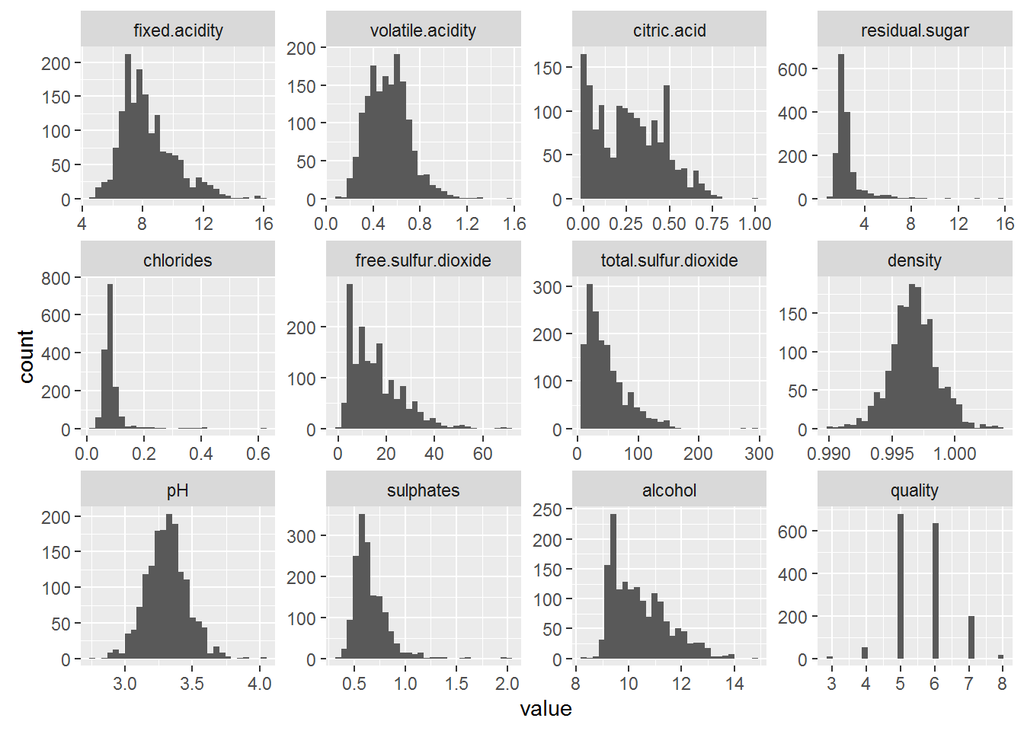

So i created td which contains melted dataset and columns variables and values Before going further we should check whether there is some missing data or values in our red wine dataset so to check that i made subset of the td such that it contains the rows with values NA in it. Then i calculate the number of rows that subset contains and the number of rows i got after running the code is zero(‘0’), it means that the dataset has no missing values in any variable (That’s a good thing!!!). Now i have created a unified plot which contains histogram for all the variables. I used facet_wrap function for creating plot for every unique variable and i used scales=‘free’ so that the plots can scale according to their values,independent of the other variables data.

Although the unified plot have all variables plot but lets create individual plot so that it will be easy to analyse the pattern more clearly.

1. Fixed Acidity

```
##    Min. 1st Qu.  Median    Mean 3rd Qu.    Max.
##    4.60    7.10    7.90    8.32    9.20   15.90
```

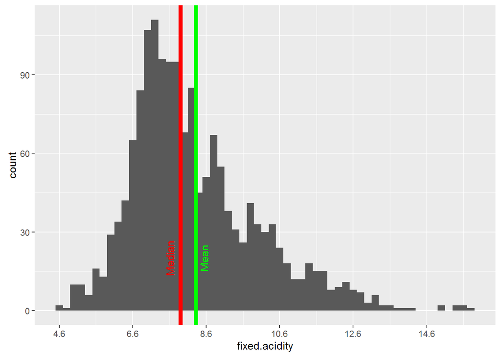

2. Volatile Acidity

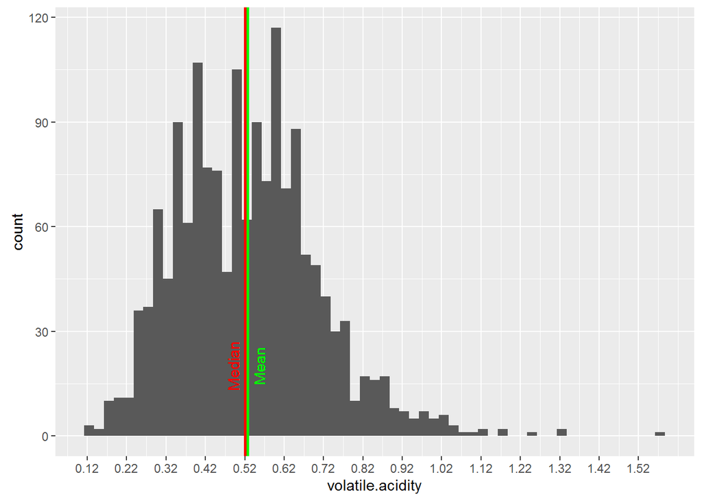

```
##    Min. 1st Qu.  Median    Mean 3rd Qu.    Max.
##  0.1200  0.3900  0.5200  0.5278  0.6400  1.5800
```

Volatile acidity is the vaporizing acidity.It ensure that the amount of acid in wine kept at good level and high value can result in unpleasant vinegar taste in wine. The histogram clearly shows that there is small number of wine which has value greater than 1. Most of the wine has value in between .17 to 1.07

3. citric.acid

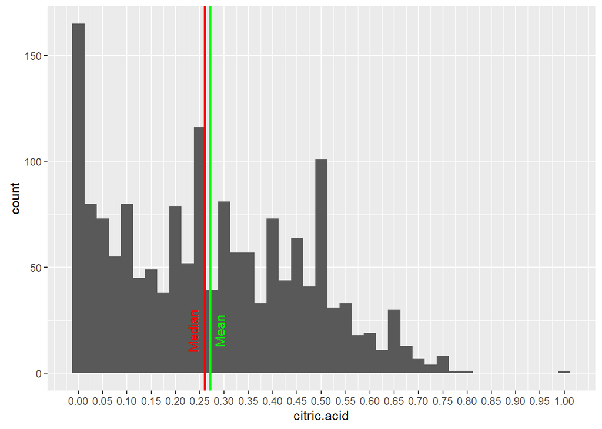

```
##    Min. 1st Qu.  Median    Mean 3rd Qu.    Max.
##   0.000   0.090   0.260   0.271   0.420   1.000
```

Citric acid found in small quantities, citric acid can add ‘freshness’ and flavor to wines. It can be seen from the histogram that wine mostly has citric acid between 0 to .75. There is only one wine observation in which the amount of citric acid is 1.

4. residual.sugar

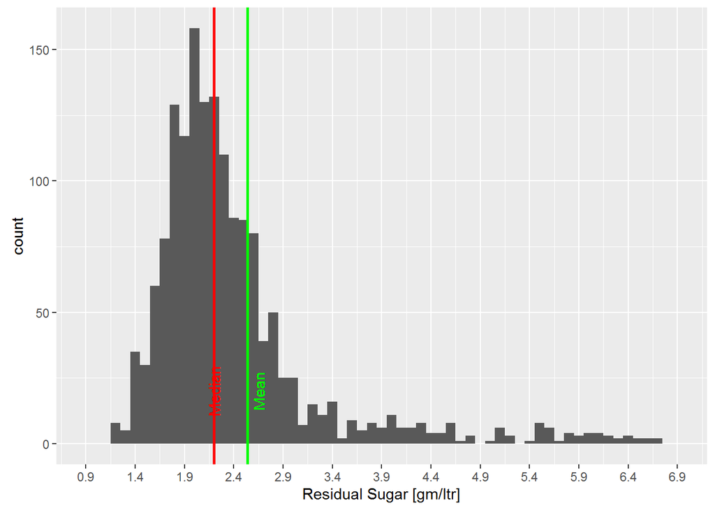

```
##    Min. 1st Qu.  Median    Mean 3rd Qu.    Max.
##   0.900   1.900   2.200   2.539   2.600  15.500
```

Residual sugar is the amount of sugar remaining after fermentation stops. The more value makes wine sweet which is not good. Less the amount better the wine. The values of residual wine in the dataset varies from .9 to 15.5 but if we see the histogram we know that most of the wine has amount of residual sugar in between the 1.4 to 3.4. I have limit the x axis from .9 to 6.9 so that the plot does not include the outliers which makes plot less descriptive

5. chlorides

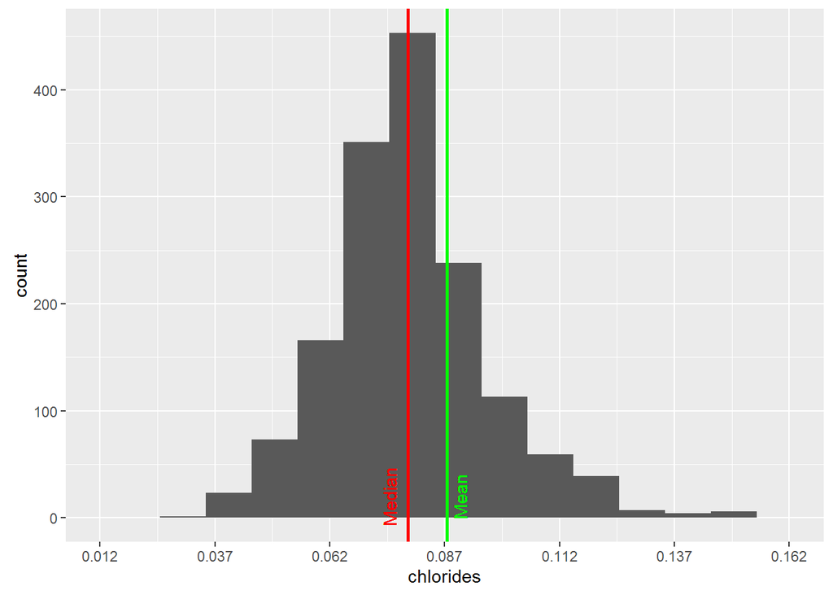

```
##    Min. 1st Qu.  Median    Mean 3rd Qu.    Max.
## 0.01200 0.07000 0.07900 0.08747 0.09000 0.61100
```

6. free.sulfur.dioxide

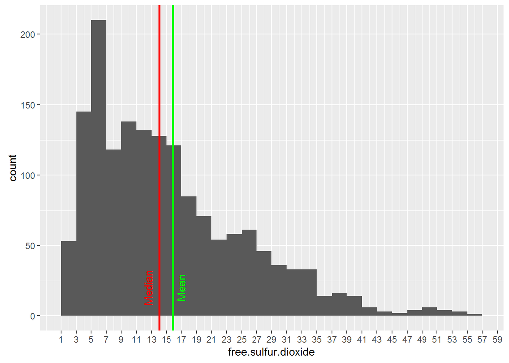

```
##    Min. 1st Qu.  Median    Mean 3rd Qu.    Max.
##    1.00    7.00   14.00   15.87   21.00   72.00
```

The Variable in the data set has values from 1 to 72 but from the histogram it is clear that most of wine in the dataset has free sulfur dioxide in between 1 to 57. So i have set the x axis limit from 1 to 57 and it also removes the outliers. There is only 4 wine observation which are removed from this range (0,57).

7. total.sulfur.dioxide

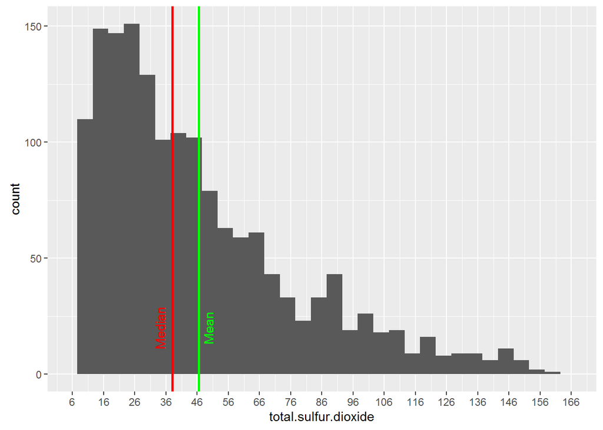

```
##    Min. 1st Qu.  Median    Mean 3rd Qu.    Max.
##    6.00   22.00   38.00   46.47   62.00  289.00
```

8. density

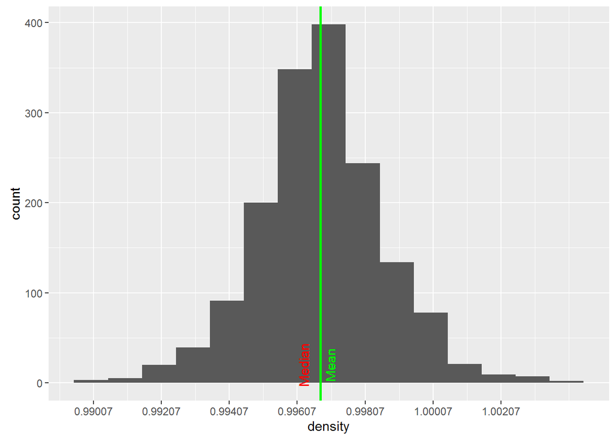

```
##    Min. 1st Qu.  Median    Mean 3rd Qu.    Max.
##  0.9901  0.9956  0.9968  0.9967  0.9978  1.0040
```

There is not much variation the values of density varies on .001 basis so there is vary less changes

9. pH

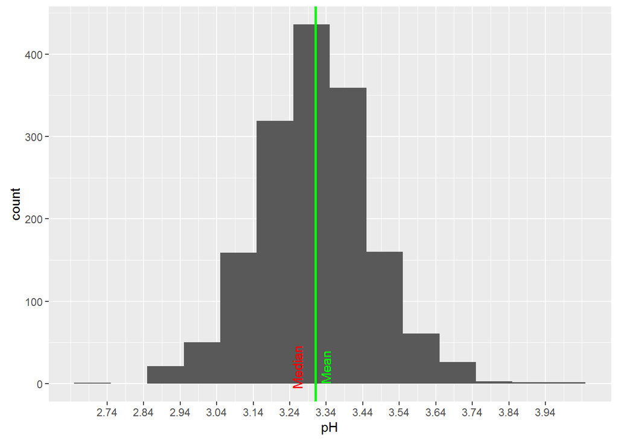

```
##    Min. 1st Qu.  Median    Mean 3rd Qu.    Max.
##   2.740   3.210   3.310   3.311   3.400   4.010
```

pH describes how acidic or basic a wine is on a scale from 0 (very acidic) to 14 (very basic); most wines in this dataset are between 2.84-3.74 on the pH scale.

10. sulphates

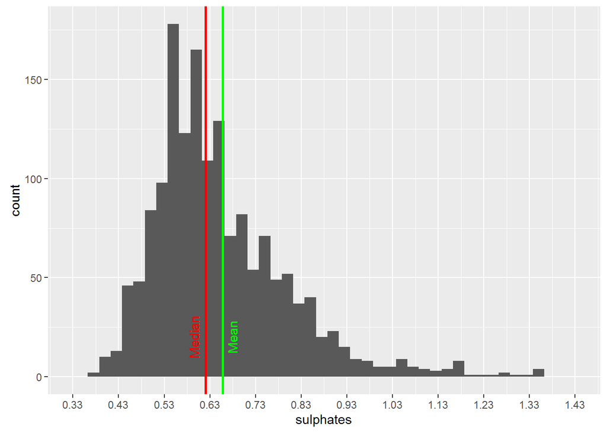

```
##    Min. 1st Qu.  Median    Mean 3rd Qu.    Max.
##  0.3300  0.5500  0.6200  0.6581  0.7300  2.0000
```

sulphate is a wine additive which can contribute to sulfur dioxide gas (S02) levels, which acts as an antimicrobial and antioxidant. the value of sulphate in the dataset varies from .33 to 2.0 but most of the values fall in the range of .43 to 1.13 so to remove the outliers i set limit of .33 to 1.43

11. Alcohol

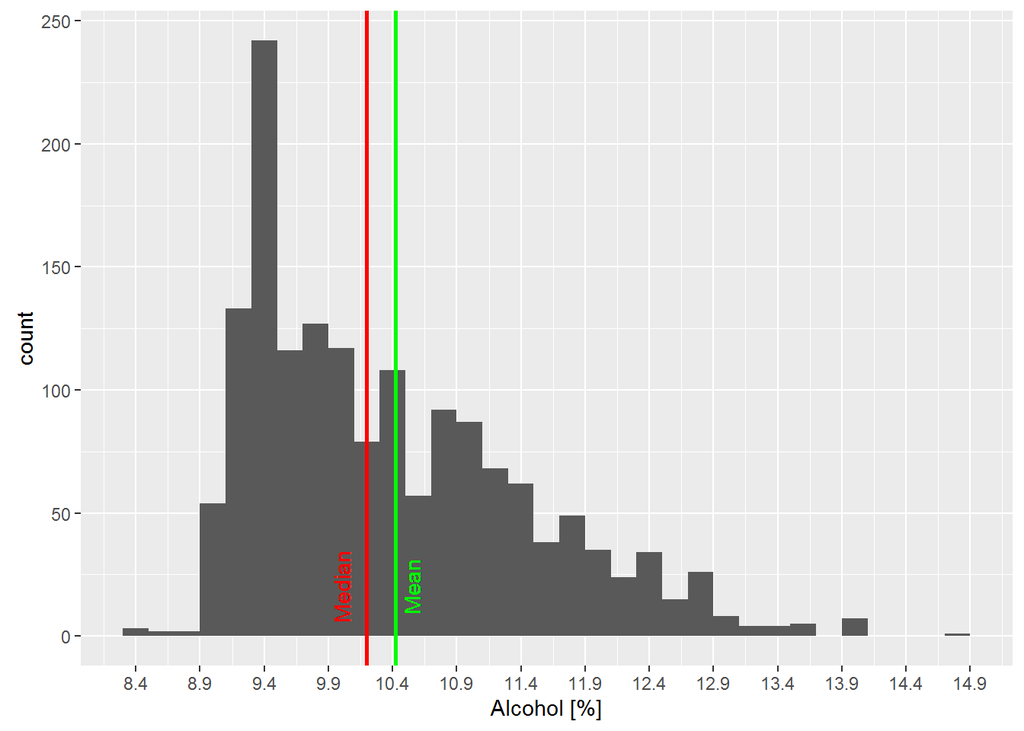

```
##    Min. 1st Qu.  Median    Mean 3rd Qu.    Max.
##    8.40    9.50   10.20   10.42   11.10   14.90
```

The amount of alcohol in the wines of provided dataset varies from 8.4 to 14.9 But from the histogram it can be seen that most of wines have values in between 8.9 to 13.4

12. Quality

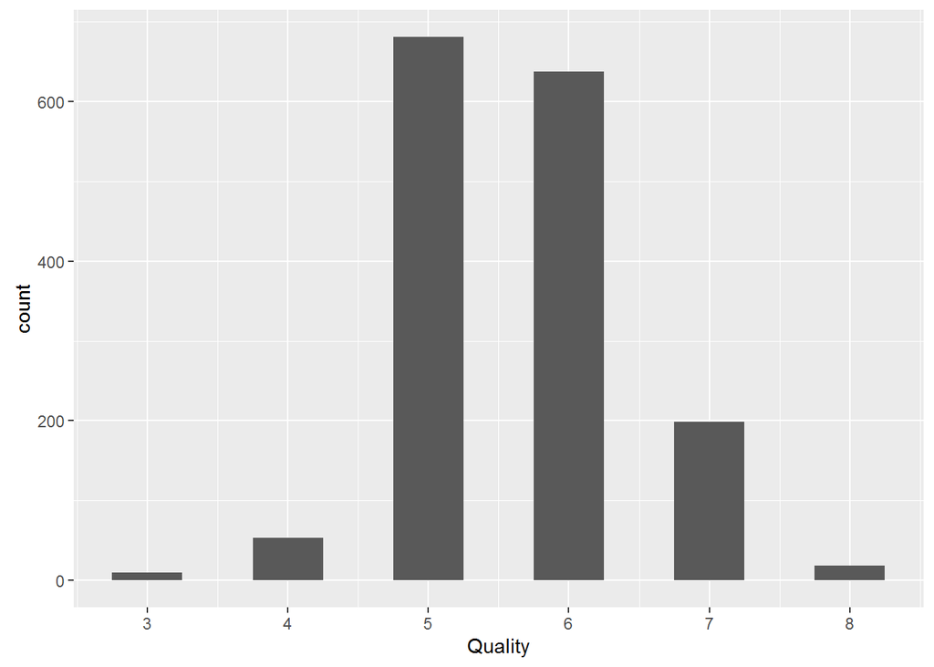

```
##    Min. 1st Qu.  Median    Mean 3rd Qu.    Max.
##   3.000   5.000   6.000   5.636   6.000   8.000
```

The most important variable in this dataset is quality value the values are on the scale of 0 to 10. In this data set the quality of wine changes from 3 to 8. From histogram it can be seen that most of wine has quality 5 or 6

# Univariate Analysis

### What is the structure of your dataset?

The data set has 13 variables but i deleted the x variable as it was just showing the indexing. the total number of different wine samples or the number of rows in the dataset is 1599. Among the 12 variables only the quality variable has integer type of values which i changed to factor and all other 11 variables are of num type i.e. they contain the floating type values. some of my observation in the dataset are:- 1. quality variable has maximum value of 8 and min value 3 so there is no whine sample in the dataset which has quality of less than 3 and greater than 8. 2. The density of the wine is approximately equal to 1. 3. PH value of red wine varies from 2.74 to 4.01 it means that the red wine is acidic in nature. 4. The maximum value of free sulfur dioxide is 72 but after value of 50 So2 become evident in the nose and taste of wine. 5. the percentage of alcohol in the red wine is between 8.4 to 14.9 (according to the dataset).

### What is/are the main feature(s) of interest in your dataset?

# Bivariate Plots Section

Now let’s create some bi variate plots.

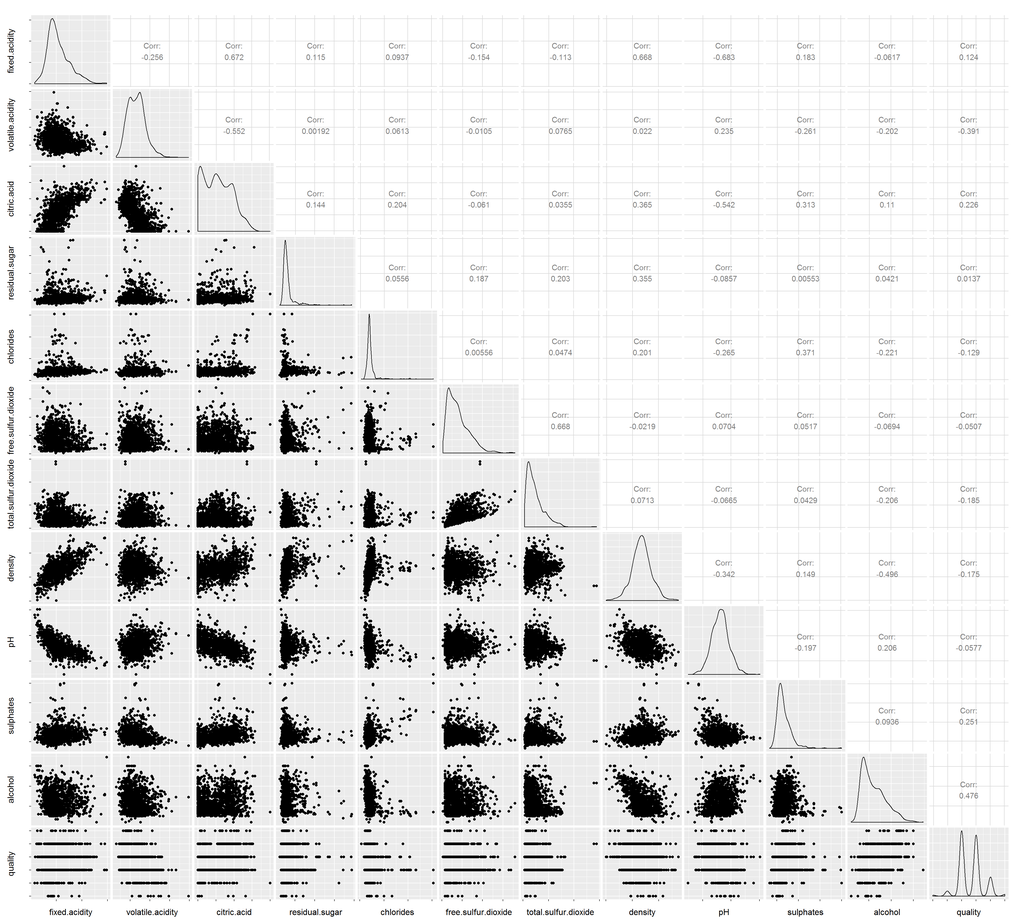

I am interested in the variation of chemicals in the wine with the quality. And this exploration can help me explore which chemicals affect wine more and how?

So the firstly according to statistical data, i have calculated the correlation coefficient of all chemicals with the quality. And these are listed below

```
##                             [,1]
## fixed.acidity         0.12405165
## volatile.acidity     -0.39055778
## citric.acid           0.22637251
## residual.sugar        0.01373164
## chlorides            -0.12890656
## free.sulfur.dioxide  -0.05065606
## total.sulfur.dioxide -0.18510029
## density              -0.17491923
## pH                   -0.05773139
## sulphates             0.25139708
## alcohol               0.47616632
```

The maximum positive value of correlation coff. with quality (0.47616632) is for alcohol so lets draw plot for it

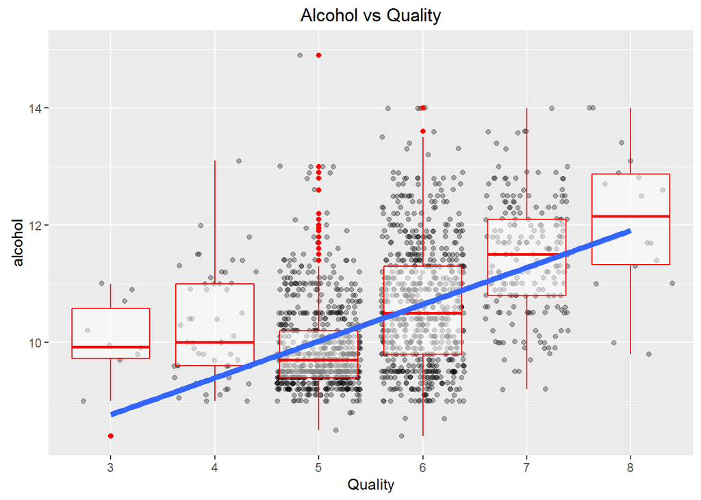

In the plot of Alcohol vs Quality it can be seen that as the quality increases the amount of alcohol in the wine also increases. I created this plot to check how the alcohol varies with the quality.

The maximum negative value of correlation coff. (-0.39055778) with quality is for volatile.acidity so to view the variation i created the plot

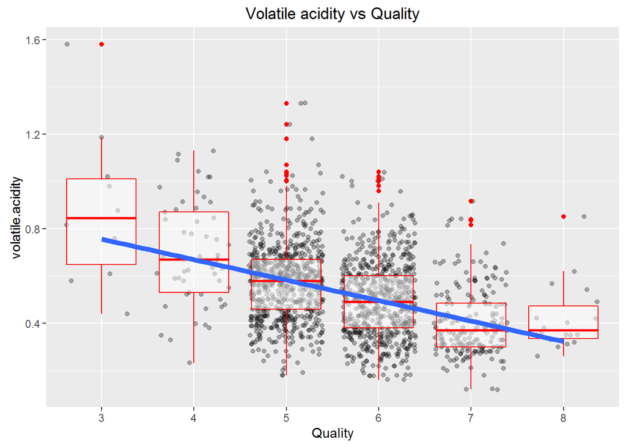

It is clear from both the plots and correlation coff. that as the volatile acidity decreases the quality increases. high quality wine tend to have less volatile acidity.

The second most positive value of correlation is with the Sulphates (0.25139708)

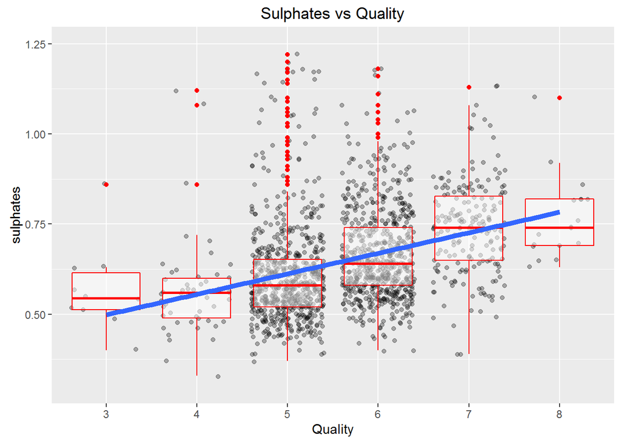

The correlation value is positive which tells that when one variable increases other also increases and it can be seen clearly that when quality increases the sulphate values also increases.High quality wines tend to have more sulphates as compare to low quality wine.

Now variation of citric acid with quality and corr. coff. is (0.22637251)

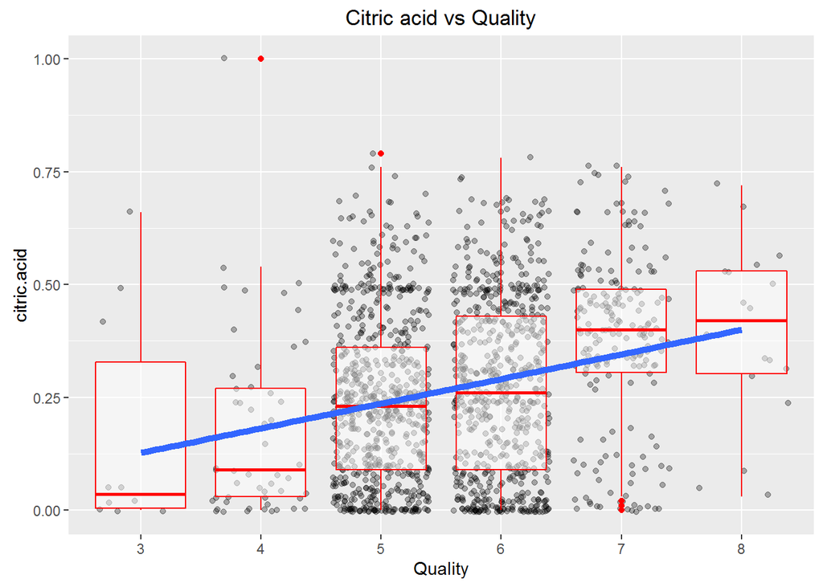

As the quality increases the wine tend to have more citric acid,citric acid increases acidity.

Now lets find the relation of pH with the quality. the correlation coff. of pH with quality is -0.05773139

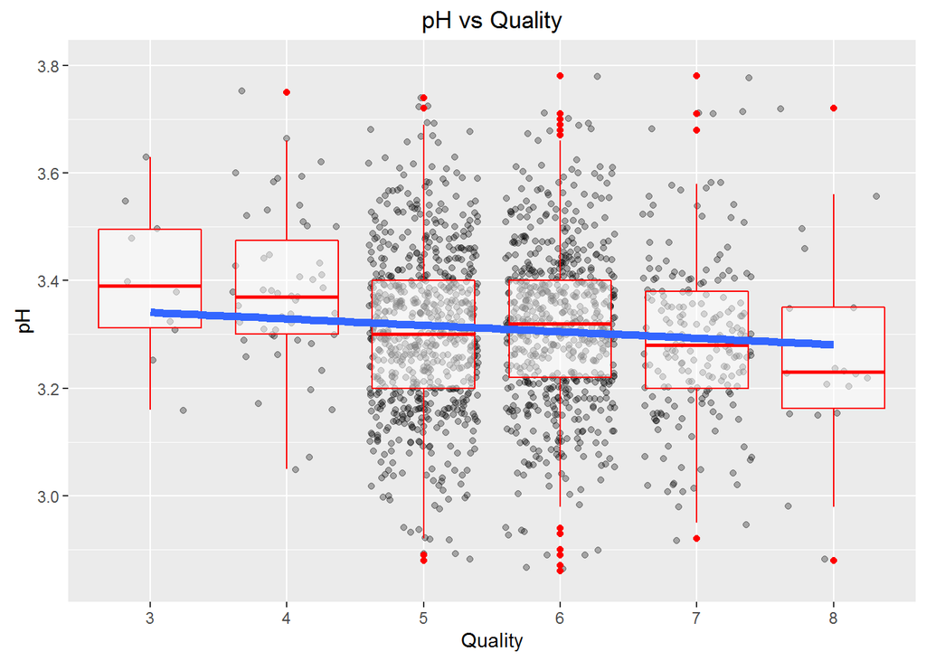

I created this plot to see how acidity of wine changes with the quality of wine. and from the plot i get to know that the wine with more acidity are good in quality.In the plot as we go towards right on the x axis means if we increases the quality the pH value decreases which means more acidic.

Now as we have some information about the relation between acidity and quality lets explore relation between other variables related to acidity. Lets find the relation between the volatile acidity and fixed acidity.

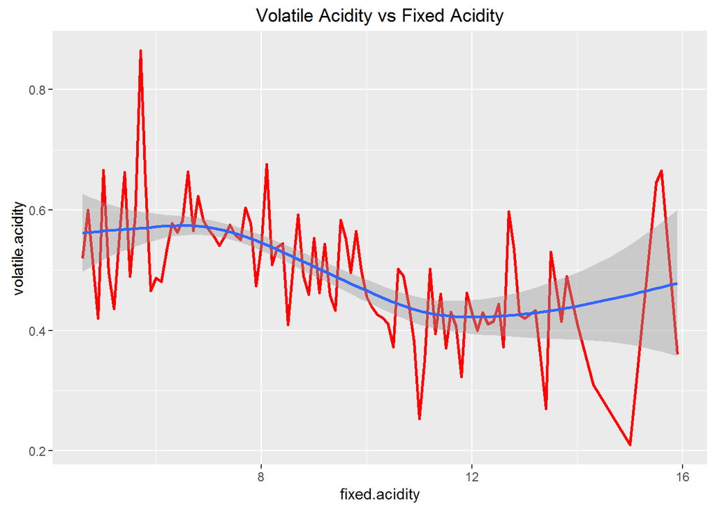

```
## [1] -0.2561309
```

The correlation between the fixed acidity and volatile acidity is negative and plot also shows that the fixed acidity and volatile acidity are reverse of each other if one increases other decreases.

Now lets check which variable among the fixed acidity and volatile acidity increases acidity of wine. And it can be found out by checking the relation of fixed acidity and volatile acidity with the pH. so i am creating a plot in between fixed acidity and pH

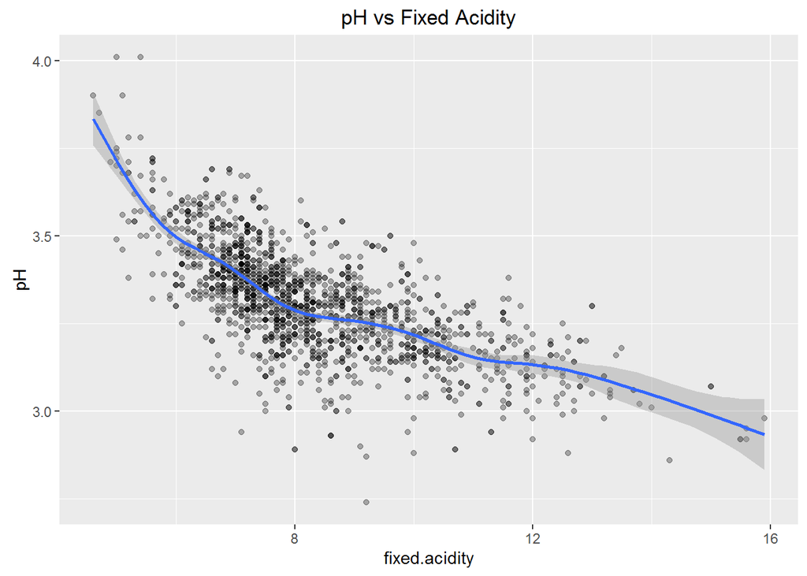

```
## [1] -0.6829782
```

we see a high correlation between the fixed acidity and pH and its negative.As the fixed acidity increases the pH value decreases and decrease in pH means more acidic so we get to know that fixed acidity increases the acidity of wine.

Now create plot between volatile acidity and pH. Although we know that fixed acidity and volatile acidity are opposite to each other so it should increase with increase in pH and correlation value should be positive.

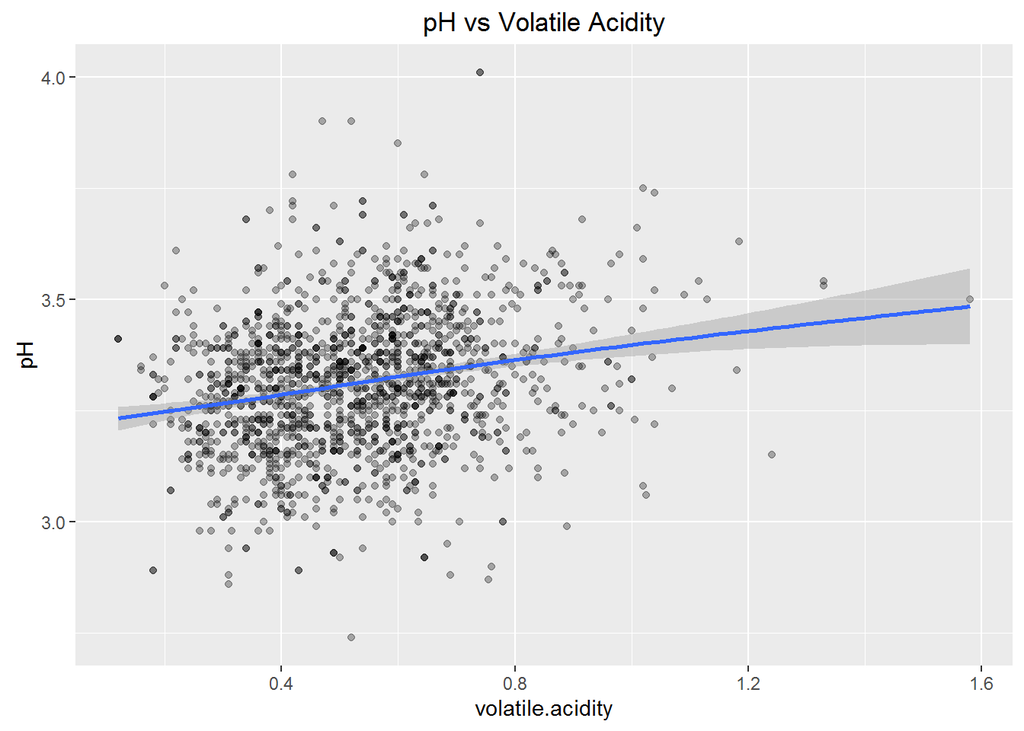

```
## [1] 0.2349373
```

the variation in volatile acidity is same as we thought the correlation coff. is 0.2349373 and it means that increase in volatile acidity means decrease in acidity of wine.

Now as this section is bi variate analysis so i should plot the variables with the maximum correlation.So to find the maximum correlation i use ggcor plot which i have created below.

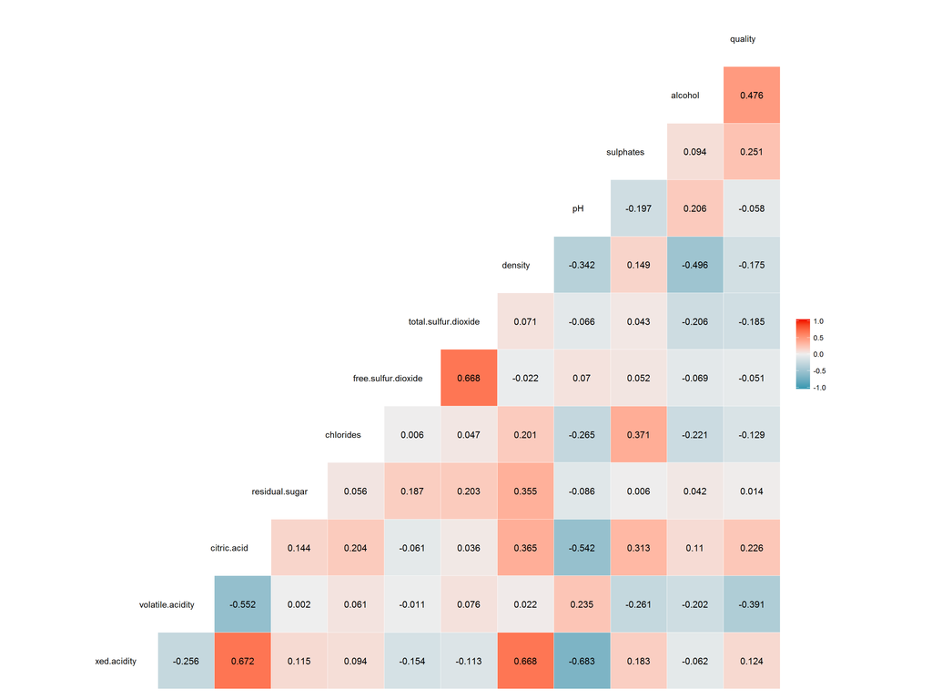

```
## [1] 0.6717034
```

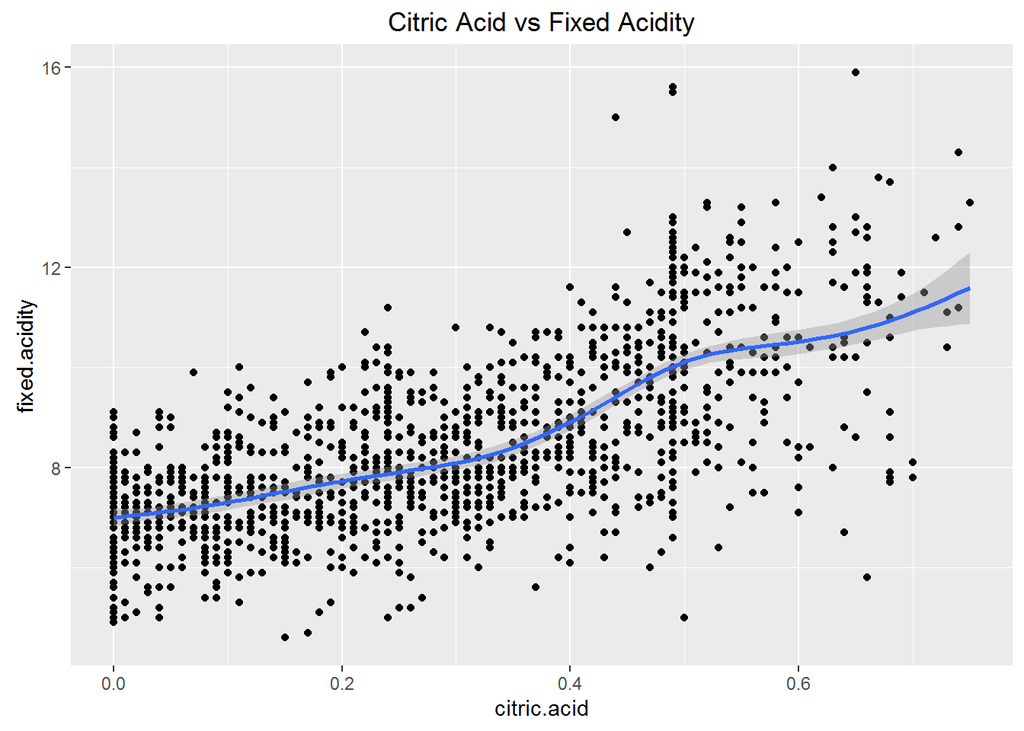

And plot shows that as the citric acid increases fixed acidity also increases.

# Bivariate Analysis

### Talk about some of the relationships you observed in this part of the investigation. How did the feature(s) of interest vary with other features in the dataset?

# Multivariate Plots Section

In bi variate plot section we varied quality with some variables so we get to know how one variable affect the quality. From bi variate plots we know that the acidity has great impact on the quality but how the quality changes with the combination of two variable it means if we combine two variable and change one another then how the quality varies. So for that i will use quality as the color factor and variables as the axes.

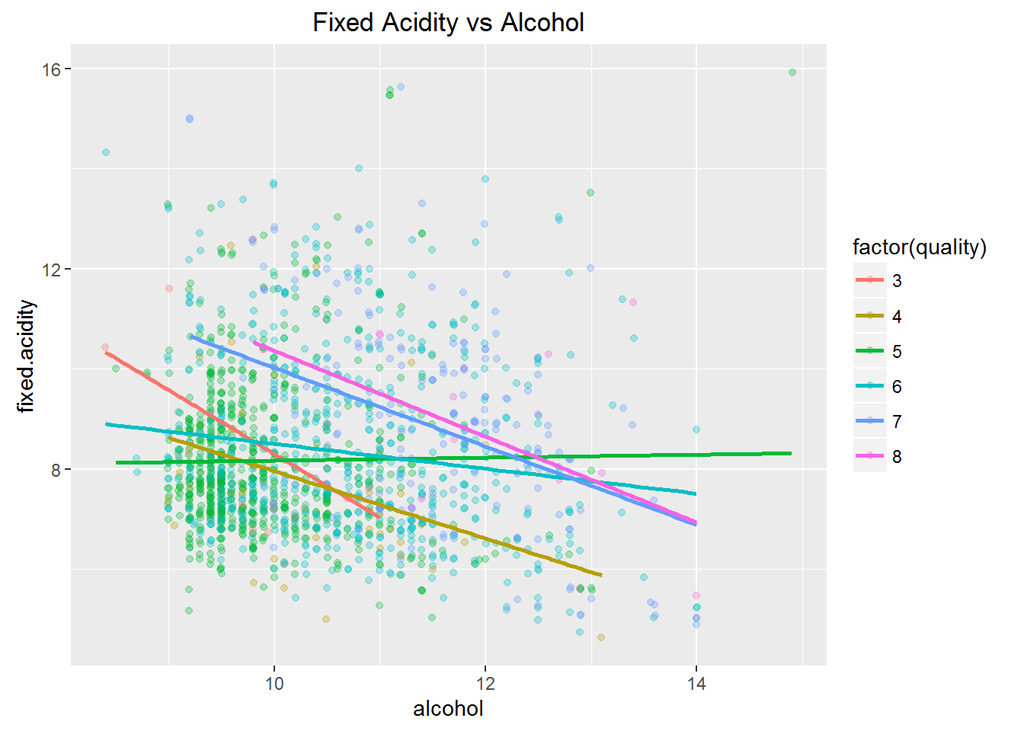

Now see relationship with Citric Acid and Alcohol

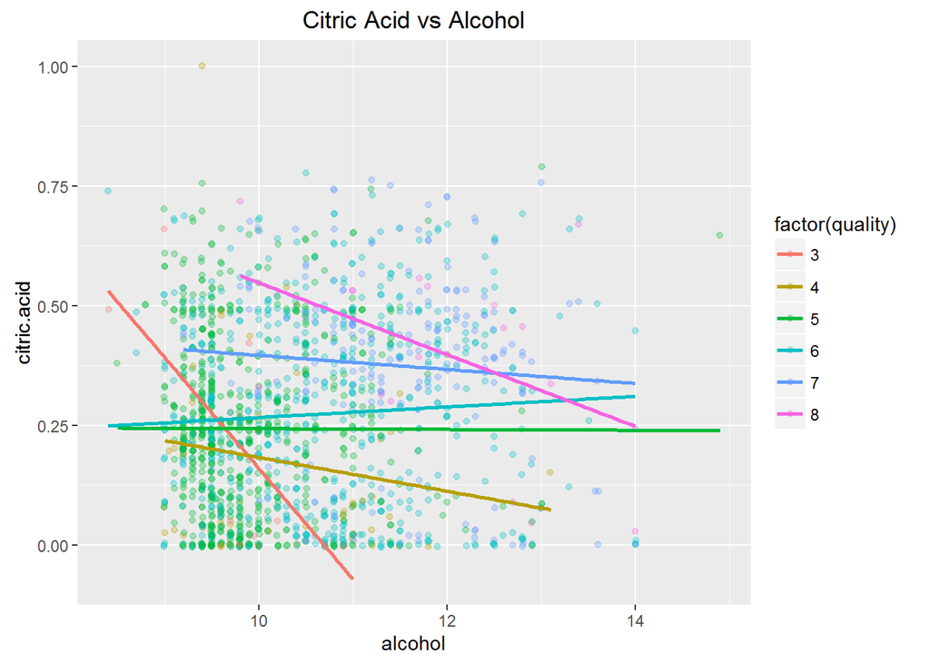

it can be seen that as the citric acid and alcohol both increases or we can say that as we go towards upper right corner the concentration of good quality alcohol increases. and when the citric acid and alcohol decreases then the quality also decreases i.e. in the lower left corner

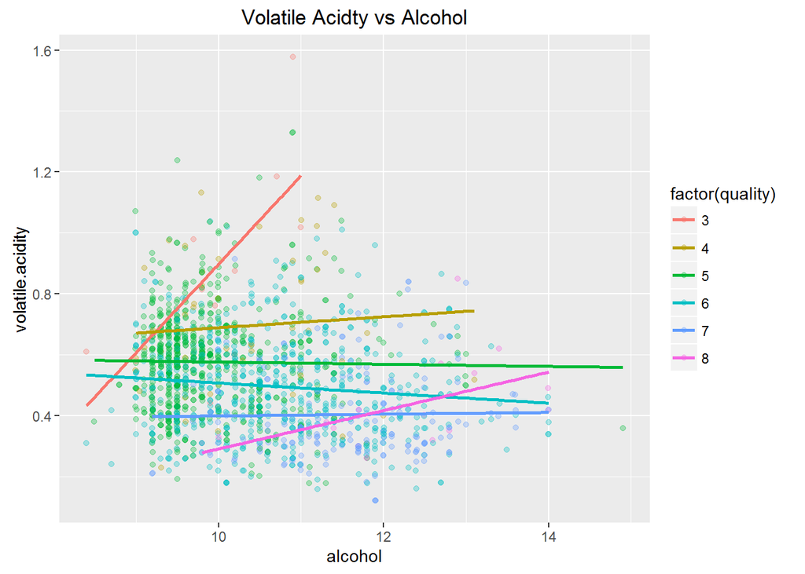

as we decrease the amount of alcohol and increases volatile acidity the quality tends to decrease but if we increase the alcohol and decrease the volatile acidity then the concentration of good quality wine increases.

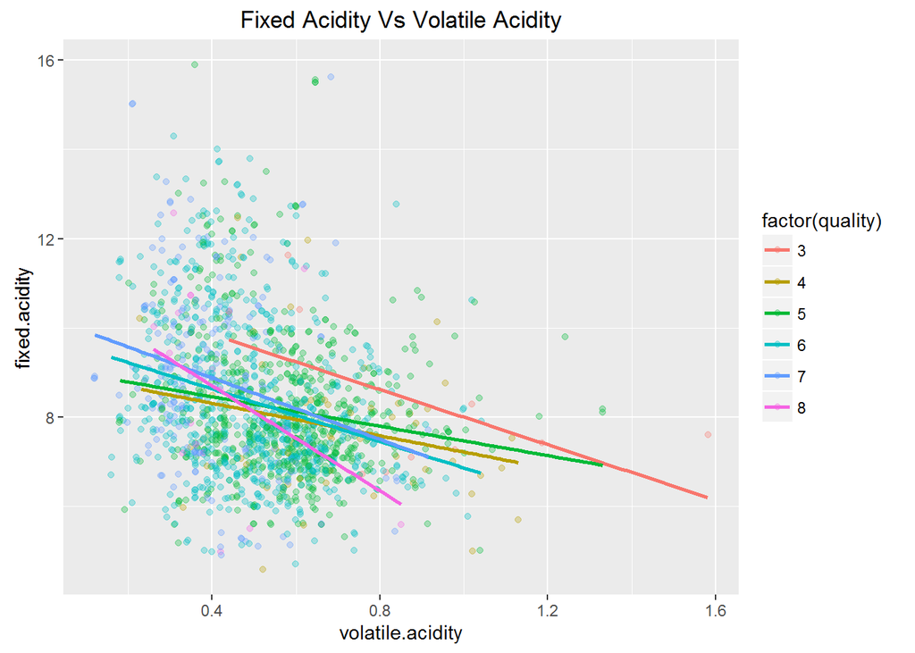

this plot gives information that less volatile.acidity and more fixed.acidity result in good quality wine

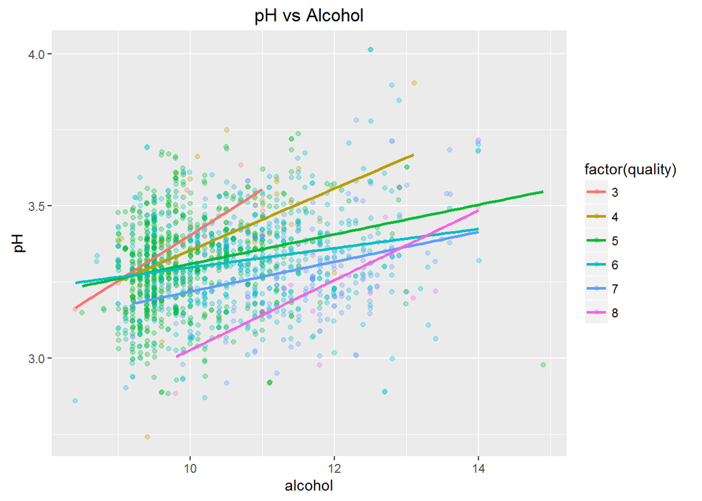

higher the pH and low alcohol makes a bad quality alcohol and higher the alcohol and less the pH makes better quality alcohol

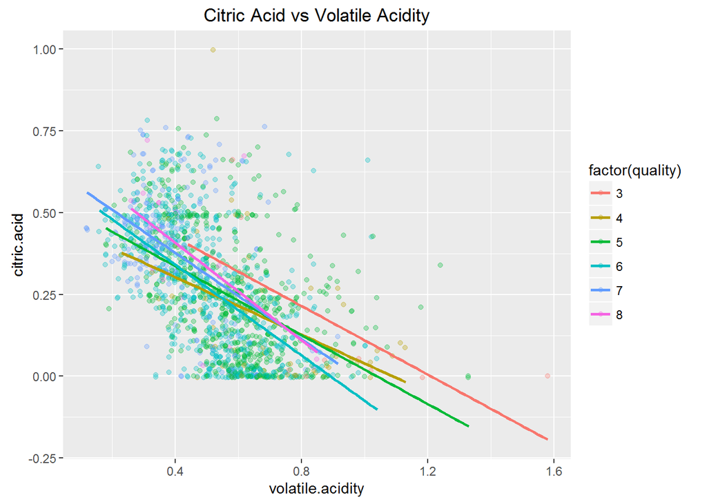

increase in volatile acidity with the increase in the citric acid result in low quality wine and decrease in volatile acidity with the increase in the citric acid produce better quality wine

# Multivariate Analysis

### Talk about some of the relationships you observed in this part of the investigation. Were there features that strengthened each other in terms of looking at your feature(s) of interest?

fixed.acidity and alcohol and citric acid and alcohol both strengthen the good quality alcohol higher the amount better the quality ### Were there any interesting or surprising interactions between features? i like interesting that fixed acidity when increased with alcohol result in good quality wine but volatile acidity when increased with alcohol decreases wine quality although both are acidic.

```
##
##  Pearson's product-moment correlation
##
## data:  rdata$fixed.acidity and rdata$pH
## t = -37.366, df = 1597, p-value < 2.2e-16
## alternative hypothesis: true correlation is not equal to 0
## 95 percent confidence interval:
##  -0.7082857 -0.6559174
## sample estimates:
##        cor
## -0.6829782
```

```
##
##  Pearson's product-moment correlation
##
## data:  rdata$volatile.acidity and rdata$pH
## t = 9.659, df = 1597, p-value < 2.2e-16
## alternative hypothesis: true correlation is not equal to 0
## 95 percent confidence interval:
##  0.1880823 0.2807254
## sample estimates:
##       cor
## 0.2349373
```

It may be due to that when we see correlation of volatile acidity with pH it is positive it means if volatile acidity increases the pH also increases which results in decrease in acidic nature of wine because more pH less acidic which result in bad quality alcohol. on the contrary the correlation between fixed acidity and pH is negative it means as the fixed acidity increases pH decreases it means more acidic which result in better quality alcohol.

```
##                        [,1]
## fixed.acidity     0.1240516
## volatile.acidity -0.3905578
## citric.acid       0.2263725
```

the correlation of fixed acidity and citric acid with quality is positive and for volatile acidity the correlation with quality is negative So the main thing is that more acidic nature of wine means high quality. ### OPTIONAL: Did you create any models with your dataset? Discuss the strengths and limitations of your model.

# Final Plots and Summary

### Plot One

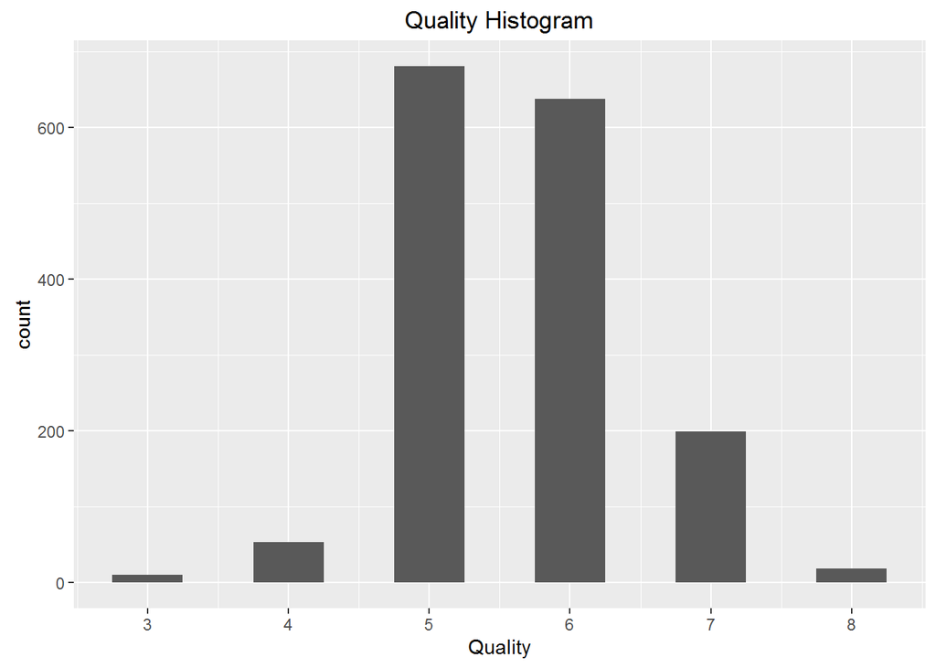

### Description One

This plot contains How many wines belong to each quality rating. This is an important histogram it gives us insight about the dataset. In dataset most of wines has quality of 5 or 6 and some wines have quality of 7. 3,4 and 8 quality wines are less in number

### Plot Two

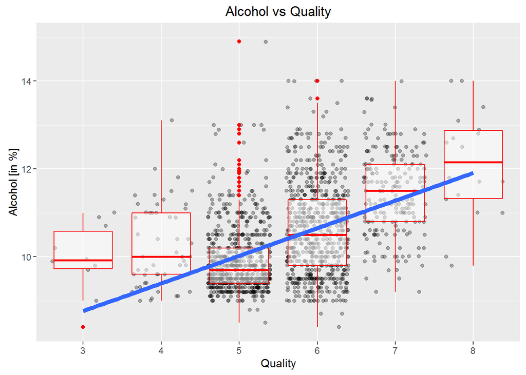

```
## [1] 0.4761663
```